# Electric consumption forecasting

| Author | Yrieix Leprince |
| --- | --- |
| Date | April 2018. |
| Context | Work done in order to enter the Craft AI startup. |
| Dataset | http://blog.drhongtao.com/2017/03/gefcom2014-load-forecasting-data.html |

The *GEFCom2014-E.xlsx* contains a dataset that stores 9 years of hourly load (I will suppose in this work that it is a domestic electric consumption record). The dataset also contains 11 years of hourly temperature in Farenheit.

```python
import pandas as pd
import numpy as np
import matplotlib.pyplot as plt
from matplotlib.cm import get_cmap
%matplotlib inline
```

```python
from jupyterthemes import jtplot
jtplot.style()
```

```python
FIGSIZE = (20,7)
FONT = {'family': 'sans-serif', 'weight': 'normal', 'size': 20}
FONTSIZE = FONT['size']
cmap = get_cmap('viridis')

path = "../data/GEFCom2014_Data/"
```

# 0. Data preprocessing

```python
df_E_raw = pd.read_excel(path+'GEFCom2014-E.xlsx')
df_E_raw = df_E_raw.rename(index=str, columns={"T": "temperature"})  # it is dangerous to have a column named T as df.T is a pandas operation
df_E_raw.index = df_E_raw.Date + pd.to_timedelta(df_E_raw.Hour -1, unit='h')
df_E = df_E_raw[['load', 'temperature']]

del df_E_raw # free memory space once the data is preprocessed
```

# 1. Time series analysis

## 1.1 First glance at the data

```python
df_E.head()
```

|  | load | temperature |
| --- | --- | --- |
| 2004-01-01 00:00:00 | NaN | 37.333333 |
| 2004-01-01 01:00:00 | NaN | 37.666667 |
| 2004-01-01 02:00:00 | NaN | 37.000000 |
| 2004-01-01 03:00:00 | NaN | 36.333333 |
| 2004-01-01 04:00:00 | NaN | 36.000000 |

```python
df_E.tail()
```

|  | load | temperature |
| --- | --- | --- |
| 2014-12-31 19:00:00 | 4012.0 | 18.000000 |
| 2014-12-31 20:00:00 | 3856.0 | 16.666667 |
| 2014-12-31 21:00:00 | 3671.0 | 17.000000 |
| 2014-12-31 22:00:00 | 3499.0 | 15.333333 |
| 2014-12-31 23:00:00 | 3345.0 | 15.333333 |

> - Data from 2004/01/01 to 2014/12/31: 11 years of data

```python
df_E.describe()
```

|  | load | temperature |
| --- | --- | --- |
| count | 78888.000000 | 96432.000000 |
| mean | 3308.000837 | 47.341571 |
| std | 579.803021 | 19.387038 |
| min | 1811.000000 | -18.000000 |
| 25% | 2845.000000 | 32.666667 |
| 50% | 3382.000000 | 48.333333 |
| 75% | 3709.000000 | 63.000000 |
| max | 5506.000000 | 97.000000 |

> - `load`: 78.888 observations and a high variance
> - `temperature`: 96.432 observations

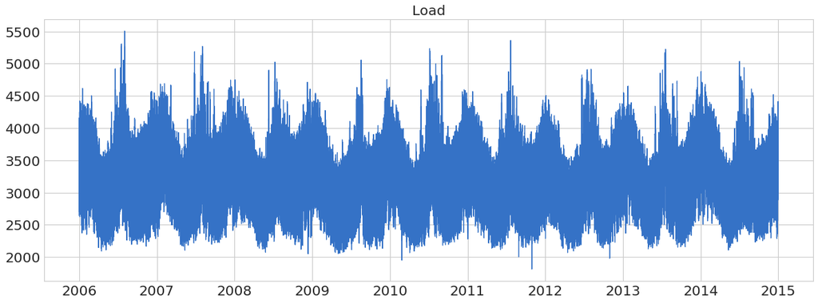

```python
df_E.load.plot(figsize=FIGSIZE, fontsize=FONTSIZE)
plt.title('Load', fontdict=FONT)
plt.show()
```

> - There is a lot of variability in the `load` records.
> - One can observe a periodicity.

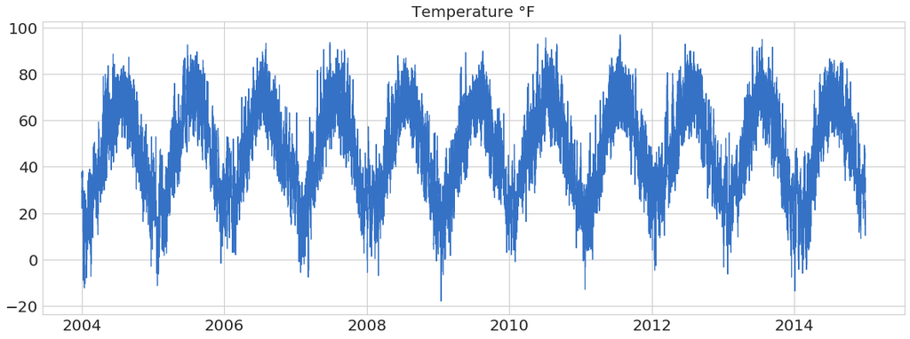

```python
df_E.temperature.plot(figsize=FIGSIZE, fontsize=FONTSIZE)
plt.title('Temperature °F', fontdict=FONT)
plt.show()
```

> - There is less variability in the `temperature` records than in the `load` one.
> - There is also a periodicity trend here.

```python
months = ['January', 'February', 'March', 'April', 'May', 'June', 'July', 'August', 'September', 'October', 'November', 'December']
to_month = lambda month_idx : months[int(month_idx) - 1]

df_E['month'] = df_E.index.month
df_E['month'] = df_E.month.apply(to_month)
```

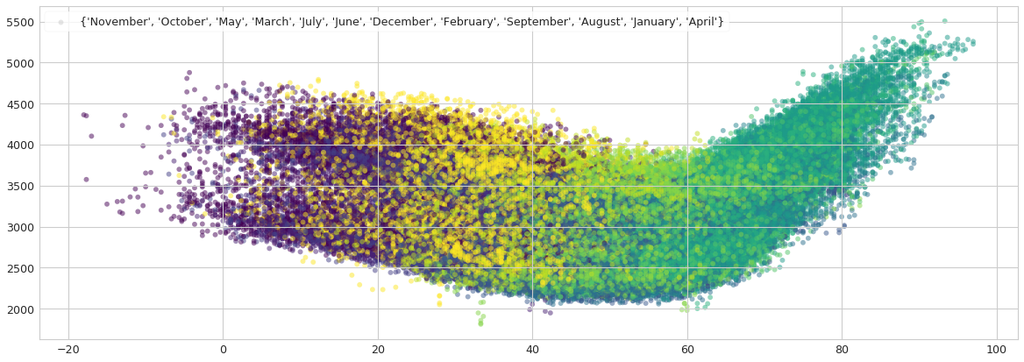

```python
plt.subplots(figsize=FIGSIZE)
plt.scatter(df_E.temperature, df_E.load, c=df_E.index.month, alpha= 0.5, cmap='viridis', label=set(df_E.month.values))
plt.legend()
plt.show()
```

## 1.2 Trends analysis

To spot the trend we will use the *rolling/moving average* method.

### 1.2.1 Monthly window

```python
window_m = 24 * 30   # 24 hours a day * 30 days a month
```

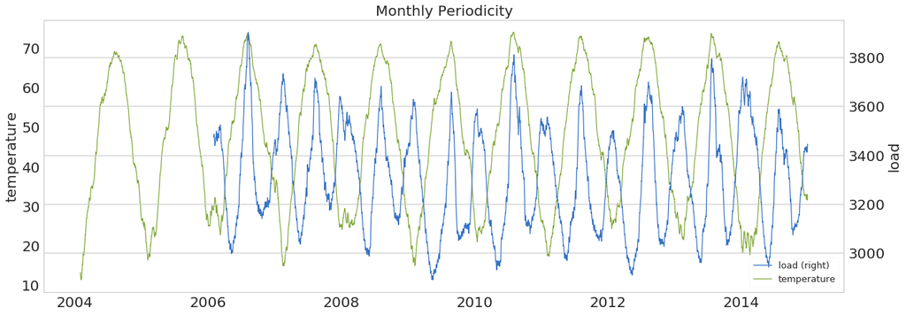

```python
ax = df_E.rolling(window_m).mean().plot(secondary_y=['load'], figsize=FIGSIZE, fontsize=FONTSIZE)
ax.set_ylabel('temperature', fontdict=FONT)
ax.right_ax.set_ylabel('load', fontdict=FONT)
plt.title('Monthly Periodicity', fontdict=FONT)
plt.show()
```

> - As observed on the first glance, both `load` and `temperature` records respect some periodicities. Here is spotted the monthly periodicity.
> - On the graph above one can see that `temperature` seems to have a period twice as long as `load`.

### 1.2.2 Yearly window

```python
window_y = 24 * 365   # 24 hours a day * 365 days a year
```

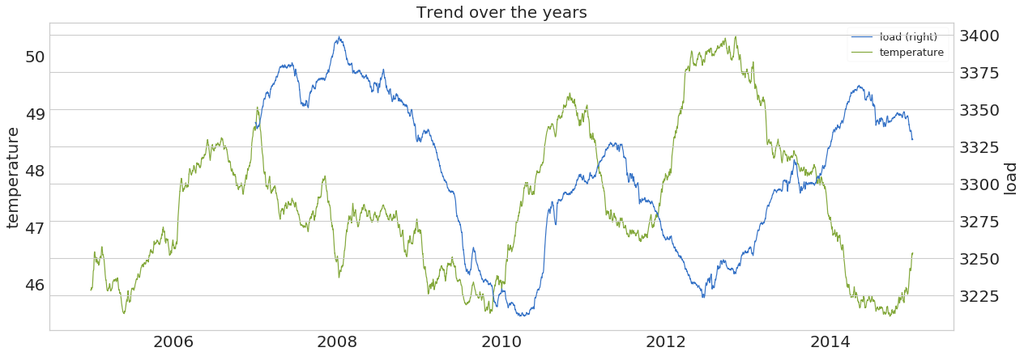

```python
ax = df_E.rolling(window_y).mean().plot(secondary_y=['load'], figsize=FIGSIZE, fontsize=FONTSIZE)
ax.set_ylabel('temperature', fontdict=FONT)
ax.right_ax.set_ylabel('load', fontdict=FONT)
plt.title('Trend over the years', fontdict=FONT)
plt.show()
```

> - By increasing the size of the rolling window we are able to spot our data's trends over the years.

## First order differencing

- In order to remove much of the trends, one can substract spotted periodicity from the value in order to convert it into a stationary timeseries (ie. timeseries whose properties do not depend on the time which the series are observed). Or an other way to proceed is to use a method call *differencing*. It computes the differences between consecutive observations.
- "*Differencing can help stabilize the mean of a time series by removing changes in the level of a time series, and so eliminating trend and seasonality.*" https://www.otexts.org/fpp/8/1

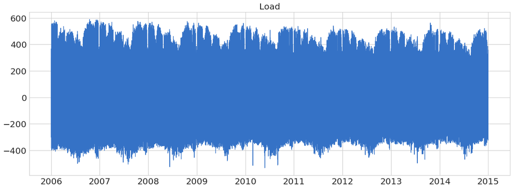

```python
df_E.load.diff().plot(figsize=FIGSIZE, fontsize=FONTSIZE)
plt.title('Load', fontdict=FONT)
plt.show()
```

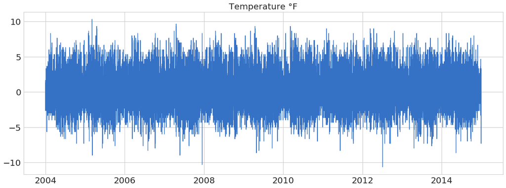

```python
df_E.temperature.diff().plot(figsize=FIGSIZE, fontsize=FONTSIZE)
plt.title('Temperature °F', fontdict=FONT)
plt.show()
```

> - One can observe that most of the trends have been eliminated. Here we are looking at the 'noise' of our timeseries.

## test

```python
from pandas.plotting import autocorrelation_plot
```

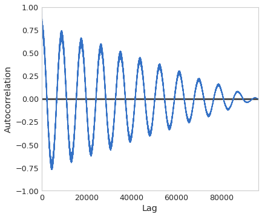

```python
autocorrelation_plot(df_E.temperature)
plt.show()
```